#Лабораторный практикум ВКИАД c R

**Преподаватель**

```
Дорошко Ольга Валерьевна
```

**Студентка**

```
Шибеко Екатерина Александровна, 2 курс, 7 группа, ПМ
```

**Вариант № 9**

### Задание 1. Управление данными в R

Загрузка данных из файла в переменную - таблицу данных.

```r
qc <- read.table("QC9.txt")
```

Размерность таблицы данных.

```r
dim(qc)
```

```
## [1] 100   9
```

Первые 3 записи таблицы.

```r
head(qc,3)
```

```
##      V1    V2 V3 V4 V5 V6    V7    V8 V9
## 1 55.48 50.75  2  2  1  4 4.565 46.77  7
## 2 60.70 54.70  2  3  1  4 4.555 47.82  6
## 3 65.12 57.66  5  1  1  4 5.765 46.44  6
```

Вывод части таблицы после переменования.

```r
names(qc) <- c("c1", "c2", "kit", "nbug", "maker", "vendor", "c3", "c4", "bug")
head(qc,5)
```

```
##      c1    c2 kit nbug maker vendor    c3    c4 bug
## 1 55.48 50.75   2    2     1      4 4.565 46.77   7
## 2 60.70 54.70   2    3     1      4 4.555 47.82   6
## 3 65.12 57.66   5    1     1      4 5.765 46.44   6
## 4 62.61 56.43   1    1     1      3 4.725 45.63   7
## 5 59.20 52.69   6    2     2      3 4.200 49.14   4
```

Комплексная статистика по переменной vendor.

```r
summary(qc$vendor)
```

```
##    Min. 1st Qu.  Median    Mean 3rd Qu.    Max.
##    1.00    2.00    3.00    2.87    4.00    4.00
```

Комплексная статистика по переменной vendor после ее преобразования в переменную-фактор.

```r
qc[,"vendor"] = as.factor(qc[,"vendor"])
summary(qc$"vendor")
```

```
##  1  2  3  4
## 14 23 25 38
```

Число изделий, у которых число дефектов (bug) больше 3.

```r
sum(qc$bug>3)
```

```
## [1] 77
```

Наблюдение, для которого количество некритических дефектов равно максимальному.

```r
qc[max(qc[,"nbug"]) == qc[,"nbug"],]
```

```
##       c1    c2 kit nbug maker vendor   c3     c4 bug
## 93 59.59 53.14   5    7     2      4 4.56 56.025   8
```

### Задание 2. Описательная статистика и графический анализ

Присоединение таблицы данных к списку текущих переменных и загрузка дополнительной библиотеки.

```r
attach(qc)
library("e1071")
```

Вычисляем среднее и медиану для переменной с1.

```r
mean(c1)
```

```
## [1] 60.7433
```

```r
median(c1)
```

```
## [1] 60.97
```

Вычисляем выборочные квартили Q1,Q2,Q3 и интерквартильный размах для переменной c1.

```r
x <- qc$c1
quantile(x,c(.25, .50, .75))
```

```
##    25%    50%    75%
## 59.430 60.970 62.285
```

```r
IQR(c1)
```

```
## [1] 2.855
```

Комплексная статистика по переменной c1.

```r
summary(c1)
```

```
##    Min. 1st Qu.  Median    Mean 3rd Qu.    Max.
##   55.13   59.43   60.97   60.74   62.28   65.74
```

Дисперсия для переменной с1 и переменной, которая представляет собой линейную комбинацию первой.

```r
var(c1)
```

```
## [1] 5.449228
```

```r
var(c1*2+100)
```

```
## [1] 21.79691
```

```r
var(c1*2+100)/var(c1)
```

```
## [1] 4
```

Вторая дисперсия больше второй в 4 раза.

Вычисление дисперсии (через вектороное выражение)

```r
sum((c1 - sum(c1)/length(c1))^2/(length(c1)-1))
```

```
## [1] 5.449228
```

Гистограмма для переменной с1.

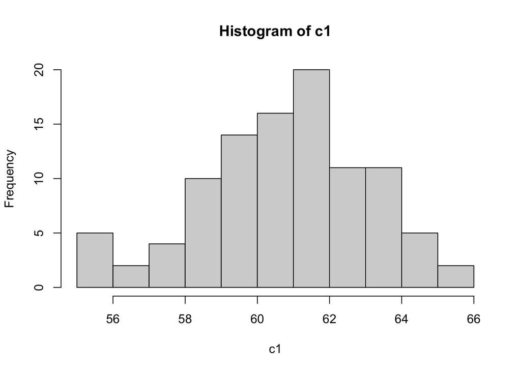

```r
hist(c1)
```

Асимметрия и эксцесс переменной c1.

```r
skewness(c1)
```

```
## [1] -0.3448012
```

```r
kurtosis(c1)
```

```
## [1] -0.2856225
```

Проверка распределения переменной c1 на нормальность с помощью статистического теста Лиллиефорса.

```r
library(nortest)
lillie.test(c1)
```

```
##
##  Lilliefors (Kolmogorov-Smirnov) normality test
##
## data:  c1
## D = 0.060892, p-value = 0.4807
```

Гипотеза о нормальном распределении не отклоняется на уровне значимости 0.05

### Задание 3. Анализ статистических зависимостей

Перекодировка переменной kit в переменную с двумя значениями (1 и 2).

```r
kit <- ifelse(qc$kit < 3, 1, 2)
```

Ранговый коэффициент корреляции Спирмена для переменных kit и maker.

```r
cor(kit, maker, method="spearman")
```

```
## [1] 0.09929932
```

Таблица сопряженности для переменных kit и maker.

```r
table(kit, maker)
```

```
##    maker
## kit  1  2
##   1 29 22
##   2 23 26
```

Cогласно ранговому коэффициенту корреляции и таблице сопряженности, согласованность между переменными практически отсутствует.

Тест на равенство нулю коэффициента корреляции для переменных с1,с3.

```r
cor.test(c1, c3, method="spearman")
```

```
##
##  Spearman's rank correlation rho
##
## data:  c1 and c3
## S = 73980, p-value = 1.899e-09
## alternative hypothesis: true rho is not equal to 0
## sample estimates:
##      rho
## 0.556076
```

Гиипотеза о равенстве нулю коэффициента корреляции между переменными отклоняется на уровне значимости.

Корреляционная матрица для числовых характеристик с1-c4.

```r
cor(qc[c("c1", "c2", "c3", "c4")])
```

```
##             c1          c2           c3           c4
## c1  1.00000000 0.875068389  0.583419330 -0.010034222
## c2  0.87506839 1.000000000  0.539350201  0.003347985
## c3  0.58341933 0.539350201  1.000000000 -0.009795793
## c4 -0.01003422 0.003347985 -0.009795793  1.000000000
```

Матрица корреляции в удобном представлении.

```r
symnum(cor(qc[c("c1", "c2", "c3", "c4")]))
```

```
##    c1 c2 c3 c4
## c1 1
## c2 +  1
## c3 .  .  1
## c4          1
## attr(,"legend")
## [1] 0 ' ' 0.3 '.' 0.6 ',' 0.8 '+' 0.9 '*' 0.95 'B' 1
```

Наибольший коэффициент корреляции между переменными c1 и с2.

Построение регрессионной модели по переменным c1 (зависимая - отклик) и с2 (независимая - фактор) и вывод общей статистики по результам оценивания.

```r
linmod = lm(c1 ~ c2)
summary(linmod)
```

```
##
## Call:
## lm(formula = c1 ~ c2)
##
## Residuals:
##     Min      1Q  Median      3Q     Max
## -3.2475 -0.6271  0.0256  0.6880  2.7174
##
## Coefficients:
##             Estimate Std. Error t value Pr(>|t|)
## (Intercept)  0.26383    3.38098   0.078    0.938
## c2           1.10549    0.06177  17.898   <2e-16 ***
## ---
## Signif. codes:  0 '***' 0.001 '**' 0.01 '*' 0.05 '.' 0.1 ' ' 1
##
## Residual standard error: 1.136 on 98 degrees of freedom
## Multiple R-squared:  0.7657, Adjusted R-squared:  0.7634
## F-statistic: 320.3 on 1 and 98 DF,  p-value: < 2.2e-16
```

Диаграмма рассеяния с линией регрессии для переменных c1 и c2.

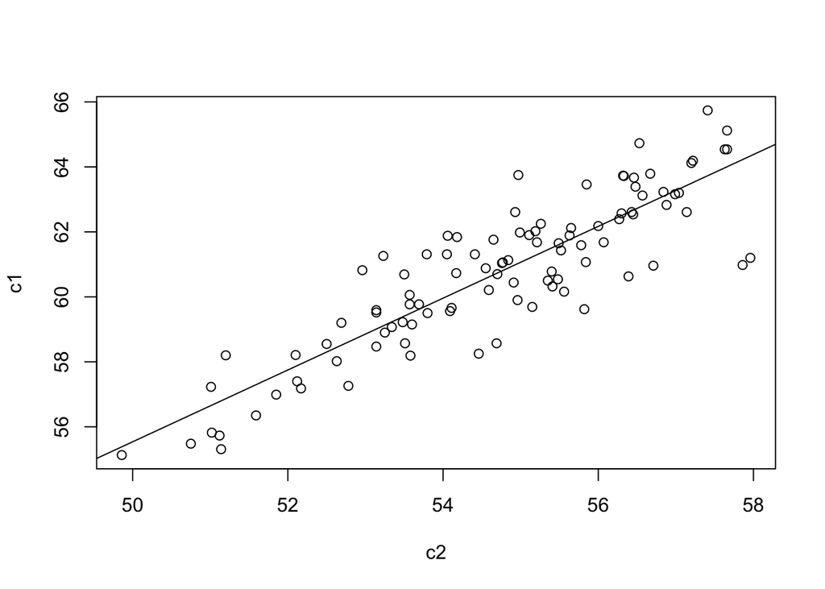

```r
plot(c2, c1)
abline(linmod)
```

Коэффициенты модели.

```r
coefficients(linmod)
```

```
## (Intercept)          c2
##   0.2638329   1.1054898
```

График “Квантиль-квантиль” для остатков модели

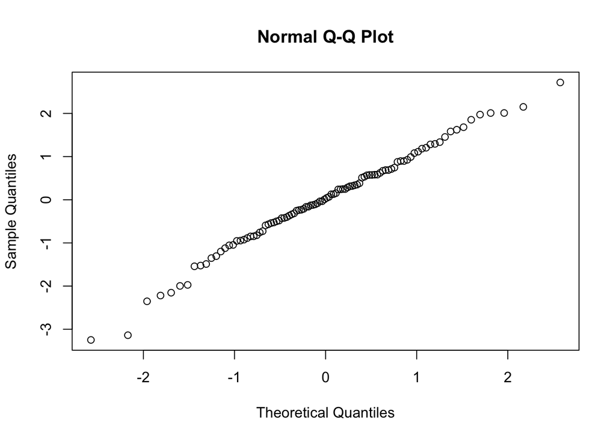

```r
res  = residuals(linmod)
qqnorm(res)
```

Большинство точек располагаются вблизи прямой линии, поэтому распределение остатков близко к нормальному.

Тест Колмогорова-Смирнова на нормальность остатков.

```r
m <- mean(res)
s <- sd(res)
ks.test(res, pnorm, m , s)
```

```
##
##  One-sample Kolmogorov-Smirnov test
##
## data:  res
## D = 0.049693, p-value = 0.9659
## alternative hypothesis: two-sided
```

Критерий не отклоняет гипотезу о нормальном распределении на уровне значимости 0.05.

### Задание 4. Анализ неоднородных данных

Частоты значений для переменной maker.

```r
table(maker)
```

```
## maker
##  1  2
## 52 48
```

Двухвыборочный t-критерий по переменной c4 c разбиением на подвыборки по переменной maker.

```r
t.test(c4 ~ maker)
```

```
##
##  Welch Two Sample t-test
##
## data:  c4 by maker
## t = -8.5391, df = 94.451, p-value = 2.26e-13
## alternative hypothesis: true difference in means is not equal to 0
## 95 percent confidence interval:
##  -4.107890 -2.558024
## sample estimates:
## mean in group 1 mean in group 2
##        48.01673        51.34969
```

Гипотеза о равенстве средних в двух подвыборках отклоняется на уровне значимости 0.05 для переменной c4(средние значения характеристики c4 у двух производителей статистически различимы).

“Ящики с усами” для переменной с4 в разрезе по номеру производителя (maker).///диаграмма размахов

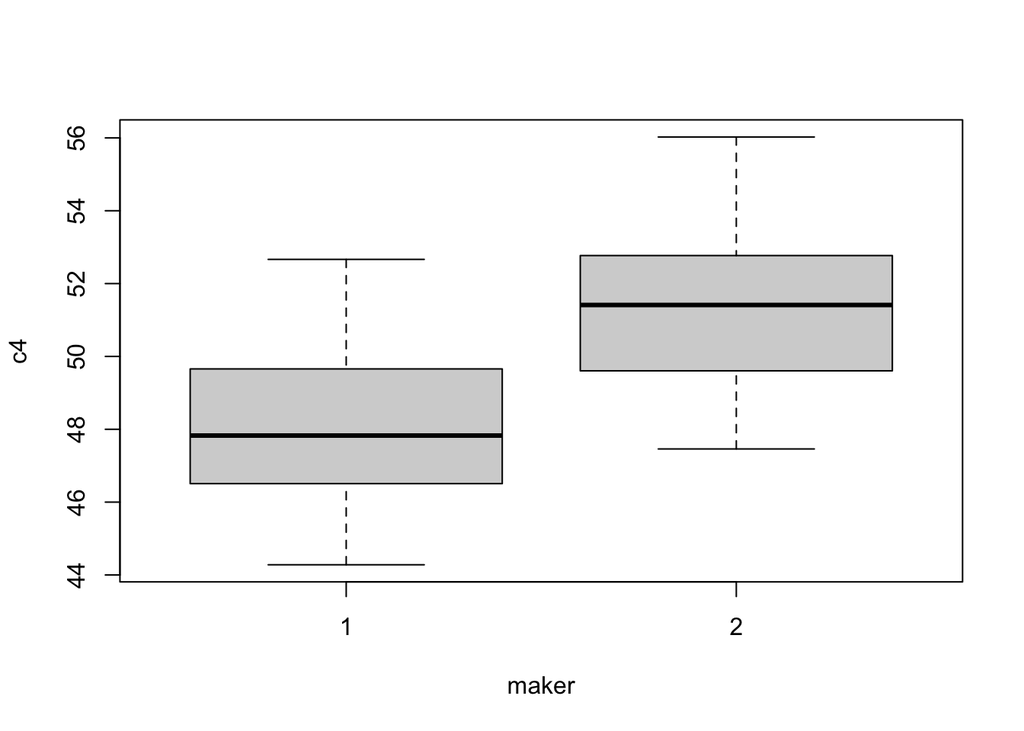

```r
boxplot(c4 ~ maker)
```

График ядерной оценки плотности распределения для переменной c4.

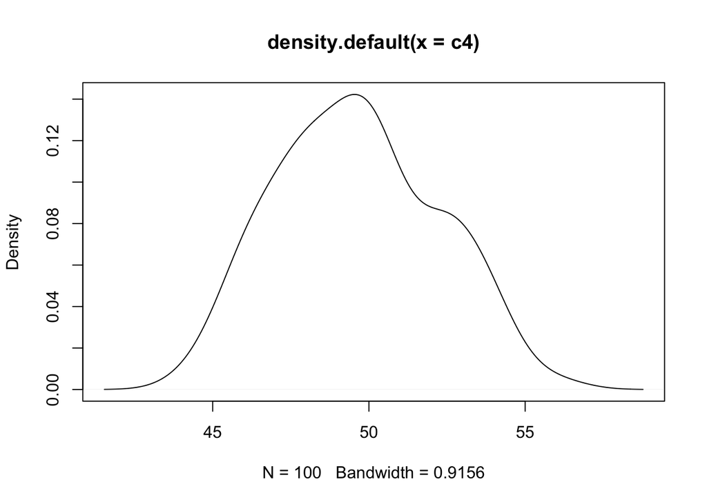

```r
plot(density(c4))
```

Из графика видно, что выборка описывается моделью , которая представляет собой смесь из двух представлений.

### Задание 5. Классификация неоднородных данных

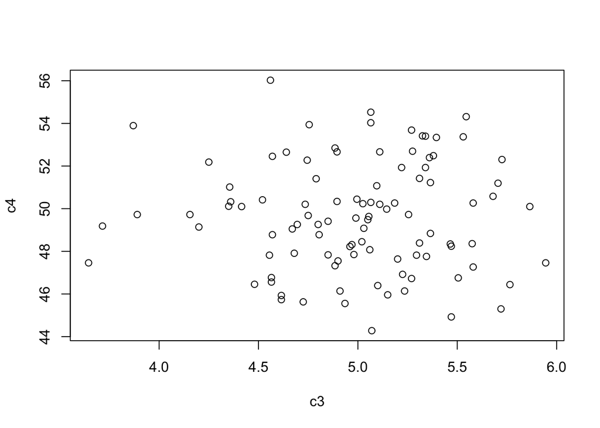

```r
plot(c3 , c4)
```

Первые строки матрицы из переменных и с4 и c3.

```r
matr <- cbind(c3 , c4)
head(matr , 3)
```

```
##         c3    c4
## [1,] 4.565 46.77
## [2,] 4.555 47.82
## [3,] 5.765 46.44
```

Применение кластерного анализа и вывод частот наблюдений в каждом оцененном классе./// cluster assigment

```r
kmres <- kmeans(matr , 2)
table(kmres $cluster)
```

```
##
##  1  2
## 45 55
```

График с классовой принадлежностью наблюдений.

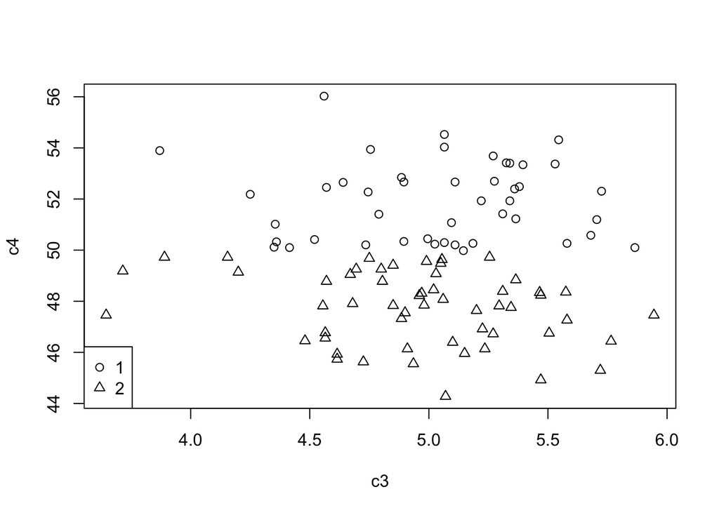

```r
plot(matr , pch  = kmres$cluster)
legend("bottomleft", legend = c("1","2"), pch = c(1,2))
```

Отсоединяем таблицу данных qc от списка текущих переменных (работа с данными закончена).

```r
detach(qc)
```